# Laboratoire du Confinement

Annotations du sentiment

CB

[figure not shown]

sideco119-merci

Ce script succède au script `DfC_extract_V01_bc` destiné à organisation la collecte et la compilation des données brutes de twitter, il a pour objet la systématisation des opération d’annotations.

# Les outils de l’analyse

Le but de l’exercice est de mesurer le sentiment dans la période covid19 au travers des twits générés avec le hashtag #confinementjourxx qui signale clairement l’intention de donner son sentiment, son humeur, sa pensée, son expérience.

```r
df<- readRDS(file = "df_26.rds")
```

# L’ évolution quantitative des tweets

On retrace ici la production des tweets, rt et comment d"heure en heure ce qui permet de capter les variations quotidiennes. On notera qu’en journée l’échantillon représente plusieurs milliers d’observations à l’heure ce qui assure une grande sensibilité des mesures. On utilise [ts_plot](https://cran.r-project.org/web/packages/TSstudio/vignettes/Plotting_Time_Series.html)

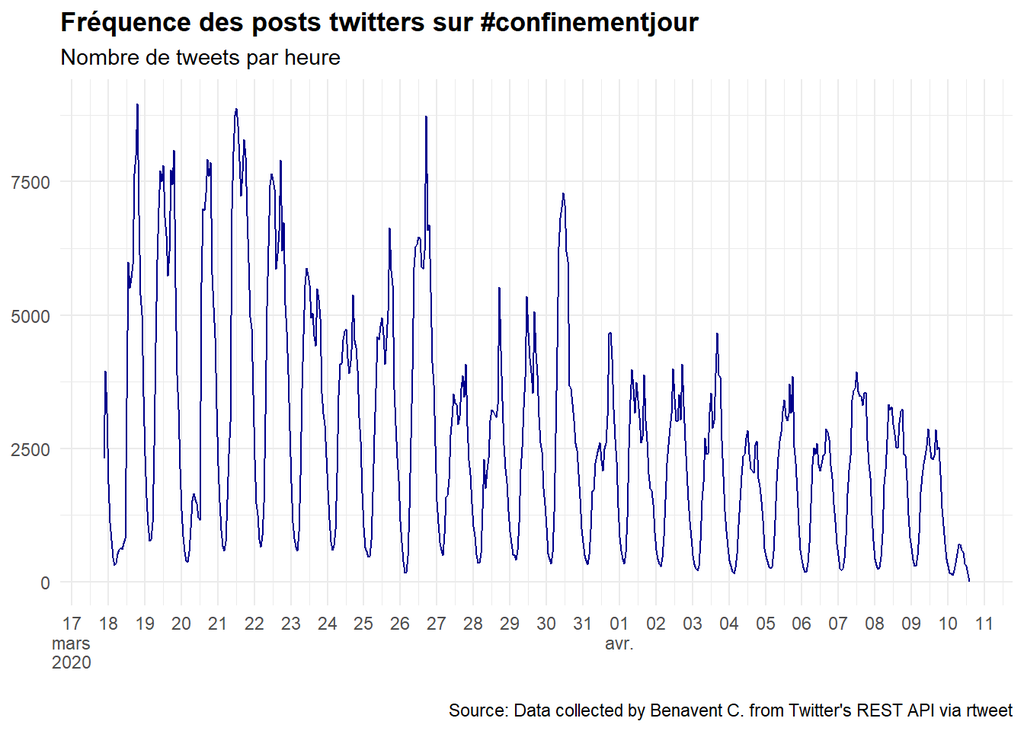

```r
## plot time series of tweets
ts_plot(df, "1 hours", color="darkblue") +
  ggplot2::theme_minimal() +
  ggplot2::theme(plot.title = ggplot2::element_text(face = "bold")) +
  ggplot2::labs(
    x = NULL, y = NULL,
    title = "Fréquence des posts twitters sur #confinementjour",
    subtitle = "Nombre de tweets par heure",
    caption = "\nSource: Data collected by Benavent C. from Twitter's REST API via rtweet"
  )+ scale_x_datetime(date_breaks = "1 day", labels = scales::label_date_short())
```

# Annotations

L’analyse du sentiment peut se faire avec plusieurs outils, on en retient pour l’instant trois, auxquels d’autres devraient être ajoutés (emoji, )

- le NCR avec le package [syuzhet](https://cran.r-project.org/web/packages/syuzhet/vignettes/syuzhet-vignette.html) On complète avec les émotions.
- le #Liwc via quanteda et le dictionnaire en français.
- le lsdfr

On en profite pour faire une analyse de fiabilité

L’unité de temps est l’heure et la journée.

On se concentrera sur les tweets informatifs : les tweets originaux et les quotes, on élimine donc les retweets de l’analyse et de l’annotation.

Ultérieurement, il sera intéressant de comparer les deux sous corpus. Le premier reflète la production primaire et originale, de ceux assez engagés pour faire l’effort de produire un contenu. Le second reflète la propagation des idées diffusées dans par le premier et les préférences des utilisateurs moins engagés, les “transmetteurs”. Ils ont le pouvoir de propager certains contenus audelà de leurs audiences immédiates et peuvent ainsi déformer la distribution des contenus, comme l’écho peut filtrer certains sons.

## Méthode NRC

On utilise le package [`syuzhet`]’(https://cran.r-project.org/web/packages/syuzhet/vignettes/syuzhet-vignette.html). La procédure est simple. On enrichit le fichier de données df de ces nouvelles annotations

```r
#require(syuzhet)
#prend bcp de temps
#paramétres
phrase<-as.character(df$text)
words<- get_tokens(phrase, pattern = "\\W")

#extraction
my_text_values_french1<- get_nrc_sentiment(phrase, language="french")

#ajout de la colonne sentiment au tableau de données général:
sent<-as.data.frame(my_text_values_french1)

library(kableExtra)
#extrait du fichier
kable(head(sent,5))

#ajout
df<-cbind(df,sent)

#on sauvegarde pour réemploi ultérieur
write_rds(df,"df_nrc.rds")
```

Une amélioration possible est la lemmatisation préalable du corpus qui devrait présenter un taux de reconnaissance plus élevé. C’est à tester de manière systématique

## Methode liwc

le LIWC dont il existe [deux versions 2007 et 2015](https://liwc.wpengine.com/compare-dictionaries/) permet d’obtenir d’autres indicateurs du sentiment, même s’il propose son propre calcul de positivité et de negativité qu’on va explité ne serait-ce que pour étblir la convergence avec l’indicateur NRC.

Une partie des 80 indicateurs proposés est relatif à des dimensions topicales dont plusieurs groupes vont retenir notre attention dans la mesure où ils décrivent une partie de l’expérience relatée dans les commentaires. On retrouvera ici les [principales variables](https://www.kovcomp.co.uk/wordstat/LIWC.html) traduction en français voir ref

La procédure pour extraire ces notions est fort simple, analogue à la précédente :

```r
# the devtools package needs to be installed for this to work
devtools::install_github("kbenoit/quanteda.dictionaries")

library("quanteda.dictionaries")
dict_liwc_french <- dictionary(file = "FrenchLIWCDictionary.dic",
                             format = "LIWC")
test<-liwcalike(df$text,dictionary = dict_liwc_french)
kable(head(test,5))

df<-cbind(df,test)
write_rds(df,"df_nrcliwc.rds")
```

Maintenant on analyse les données, plus de 80 colonnes se sont ajoutées à notre fichier.

## Méthode lsd

Lexicoder en français est du à @duval_analyse_2016. [voir aussi](https://www.poltext.org/fr/donnees-et-analyses/lexicoder). On utilise la version adaptée pour quanteda.

```r
dictfile <- tempfile()
download.file("http://dimension.usherbrooke.ca/voute/frlsd.zip", dictfile, mode = "wb")
unzip(dictfile, exdir = (td <- tempdir()))
dic_ton <- dictionary(file = paste(td, "frlsd.cat", sep = "/"))
df_senti<-df$text %>% tokens(what = "word", remove_numbers = TRUE,
                              remove_punct=TRUE, remove_symbols = TRUE,
                              remove_separators = TRUE, remove_twitter = TRUE,
                              remove_hyphens = FALSE, remove_url = TRUE,
                              ngrams = 1L)
senti<-tokens_lookup(df_senti, dictionary = dic_ton, exclusive = FALSE)
#head(senti,2)
#Application du dictionnaire des sentiments: obtient l'occurence des termes positifs et des termes négatifs par commentaire
analyseSentiments <- dfm(df_senti, dictionary = dic_ton)
#Transformation en un data.frame avec transformation du nom des variables

dfBaseSpecifique=data.frame(analyseSentiments,nb=ntoken(df_senti), id=rownames(df))
dfBaseSpecifique<-dfBaseSpecifique %>% rename(Pos_lsdfr=POSITIVE, Neg_lsdfr=NEGATIVE)
df_lsd<-cbind(df,dfBaseSpecifique)

M<-subset(df_lsd, select=c(anger, anticipation,disgust, fear, joy, sadness, surprise,trust, negative, positive,émopos,émonég,Pos_lsdfr,Neg_lsdfr))
M <- cor(M)
library(corrplot)
corrplot.mixed(M, order="hclust")
```

## Méthodes sur mesure

Si la notion de sentiment se rapporte à l’idée de valence (+/-) et que les instruments diffèrent par leurs dictionnaires, on peut être tenté d’en construire un propre au corpus et à ce que l’on souhaite observer. Mieux on peut généraliser l’idée en abandonnant la valence pour créer des indicateurs plus topicaux ( avec un index absence/présence).

Par exemple puisque la nourriture semble jouer un rôle important dans l’expérience de confinement, on peut annoter nos texte sur la base de la fréquence avec laquelle une liste de mots bien définis apparaissent dans le texte.

```r
my_text <- df$text
method <- "custom"
custom_lexicon <- data.frame(word=c("course", "shopping", "queue", "masque","un mètre",
                                    "distance sociale","commerce","supermarché","superette","marché",
                                    "faire ses courses", "employé","caissière", "carrefour", "leclerc",
                                    "Intermarché", "franprix","monoprix" ),
                             value=c(1,1,1,1,1,1,1,1,1,1,1,1,1,1,1,1,1,1))
custom_distrib <- get_sentiment(my_text, method = method, lexicon = custom_lexicon)

custom_distrib<-as.data.frame(custom_distrib)
ggplot(custom_distrib,aes(x=custom_distrib))+geom_histogram()+scale_y_log10()
```

Dans le cas du confinement, l’enjeu serait de caractériser l’expérience vécu. Ses facette principales sont a priori, mais l’analyse des études qualitatives proches de cette problématiques peuvent être utiles pour mieux en cerner les dimensions.

Une analyse phénoménologique rapide en fait émerger quelques unes (à augmenter et mieux reclasser) :

Comportement * Travail :le travail qui soit se fait à distance soit dans des conditions de circulations fortement contraintes * Education : S’occuper de la vie des enfants : écoles, aération, occupation, disputes…. * Socialité :Le rapport aux autres des proches éloignés au lointains rapprochés * Organique : Le soin du corps et la sexualité, l’organique. * Logistique : l’approvisionnement et l’alimentation * Sécurité : les gestes de protection

Sentiment, émotions et états d’ames * L’inoccupation et l’ennui * La spatio-temporalité et la perte des repère ( désorientation) * La catharsis, la distanciation par l’humour et l’irone, la tentation du contrôle par l’information. * Les émotions

Cognition

##le traitement des emojis.

c’est une question essentielle mais résolue par [Sophie Balech](https://benaventc.github.io/BarometreConfinement/confinement02_emojis.html) …..

## Approche via ML

mais quelle variable à prédire? l’annotation manuelle est difficile, pas de note associée, seulement des mesures de succès (rt, reply),

##Références :